# Assignment 3B WB

Peter Dolan

#### INSTRUCTIONS:

- Type your answers on the space provided under each problem.
- You can embed an R code chunk like this:

  ```r
  summary(cars)
  ```

  ```
  ##      speed           dist
  ##  Min.   : 4.0   Min.   :  2.00
  ##  1st Qu.:12.0   1st Qu.: 26.00
  ##  Median :15.0   Median : 36.00
  ##  Mean   :15.4   Mean   : 42.98
  ##  3rd Qu.:19.0   3rd Qu.: 56.00
  ##  Max.   :25.0   Max.   :120.00
  ```

- After you are done click the **Knit HTML** button. A document will be generated that includes both content as well as the output of any embedded R code chunks within the document.
- Go to File –> Save. Name your file.
- Upload the file to Canvas using the link provided.

Start by loading the package `xml2` (install the package if necessary):

```r
library(xml2)
```

Review the contents of the web page we consulted in Assignment 2: http://www.diabetes.org/diabetes-basics/statistics/

Accessing that webpage redirects us to a new address https://www.diabetes.org/resources/statistics/statistics-about-diabetes. Some scraping libraries work well with this (such as `rvest`). Others do **not** (such as `XML`). So it’s worth paying careful attention to these details.

The `rvest` package seems to be increasing in popularity so we’ll use that. Below is a basic outline of how to **scrape data** using `rvest`. The functions in parentheses will be discussed further below:

1. Identify the URL of the webpage
2. Identify WHERE the desired information lives on the webpage (manual inspection of web page and XPATH)
3. Create a variable for interacting with webpage (`read_html()`)
4. Extract desired nodes from step 2 (`xml_find_all()`,`html_nodes()`) and make them more useable (`xml_ns_strip()`). This might involve several rounds of processing and refinement.
5. Extract node information from step 4 (`html_text()` and/or `xml_text()`)
6. Use R to processing node information into useable form (text manipulation including regular expressions)
7. (optional) Compile the various data items from step 6 into a useful form

So… let’s load rvest:

```r
library(rvest)
```

Note that `rvest` depends upon `xml2`.

**Step One:** The url that we want is:

```r
url="https://www.diabetes.org/resources/statistics/statistics-about-diabetes"
```

**Step Two:** Our goal is to access the **Diabetes by race/ethnicity** data. If we right-click on one of the numbers and choose “Inspect” (if you’re using Chrome) then we see that our desired information is a list item `<li>...</li>` that is part of an unordered list `<ul>...</ul>`.

*Foreshadowing:* Instead of trying to be too clever, we will:

- extract all the `<UL>` nodes from the page
- find the one with the word “Hispanic” (we’ll do this in R but it can be done in XPATH too) and then
- extract the `<LI>` nodes

**Step Three:** put the page in a variable and remove the namespace restrictions:

```r
wb=read_html(url)
wb=xml_ns_strip(wb) #Remove name spacerestrictions
```

**Step Four (part 1):** Extract the `<UL>` nodes:

```r
list.nodes=html_nodes(wb,"ul")
```

**Step Four (part 2):** Identify the `<UL>` node that want:

We want the `<UL>` node that has the statistic for “Hispanics”. We’ll use `html_text()` to turn the node-set into text that we can search using `grep`:

```r
list.text=html_text(list.nodes)
n=grep("Hispanics",list.text)
n
```

```
## [1] 112
```

```r
dlist=list.nodes[n]
```

Found it in entry 112.

**Step Four (part 3):** Extract the `<LI>` nodes:

The list entries are `<LI>` nodes. We’ll use `html_node()` to get those nodes:

```r
li.nodes=html_nodes(dlist,"li")
```

**Step Five:** Extract the text from the `<LI>` nodes:

Use `html_text()` to extract their text:

```r
entries= html_text(li.nodes)
```

**Step Six:** Process the extracted text into a useful form:

We’ll use regular expressions to extract what we want from the text. This will take some work… so look at the code and then read the explanation below.

*Extracting the percentages:*

```r
library(stringr)
d.percents=str_extract(entries,"[0-9]+[.][0-9]+")
d.percents
```

```
## [1] "14.5" "12.1" "11.8" "9.5"  "7.4"
```

Notice the expression “[0-9]+[.][0-9]+”. That means

- one or more digits [0-9]+
- followed by a period [.]
- followed by one more digits [0-9]+

*Extracting the ethnicities (approach 1):*

This requires a bit more work. Two answers spring to mind. The first takes advantage of the regular structure of the words:

```r
str_sub(str_extract(entries,"of.*$"),4)
```

```
## [1] "American Indians/Alaskan Natives" "non-Hispanic blacks"
## [3] "Hispanics"                        "Asian Americans"
## [5] "non-Hispanic whites"
```

Here we used `str_sub()` (from `stringr`) to, essentially, lop-off the first few characters. This approach starts by matching “of” then grabs everything (.*) until the end of the string ($).

*Extracting the ethnicities (approach 2):*

A more flexible approach, but one that requires a MUCH better understanding of regular expressions, uses a type of non-consuming match called a **look-behind** match. (Something not discussed in your book or any of the online resources that we provided) To use this feature, we will need the regular expression syntax from a language called PERL. The `stringr` library is perfectly fine with this, as long as we surround the pattern with the function `regex()`. This is probably best understood with an example:

```r
d.eth=str_extract(entries,regex("(?<=of[[:whitespace:]]).*$"))
d.eth
```

```
## [1] "American Indians/Alaskan Natives" "non-Hispanic blacks"
## [3] "Hispanics"                        "Asian Americans"
## [5] "non-Hispanic whites"
```

All the magic lives in this expression: `(?<=**...**)`

The outer parenthesis tell us that some sort of grouping (or capturing) is taking place. The `(?<=` at the beginning of the pattern is PERL-code for “look for this pattern but don’t add it to the match”. It can ONLY be used **before** a normal-style match.

**Step Seven:** Make a data frame:

So… as a final step, we could make our own data-frame:

```r
data.frame(percent=d.percents,ethnicity=d.eth)
```

```
##   percent                        ethnicity
## 1    14.5 American Indians/Alaskan Natives
## 2    12.1              non-Hispanic blacks
## 3    11.8                        Hispanics
## 4     9.5                  Asian Americans
## 5     7.4              non-Hispanic whites
```

Now this example is a little bit contrived– it might have been easier to enter the data by hand, however this process lends itself well to automation– and will continue to work if the data changes (but retains its format), or if the web-page undergoes minor modifications.

Let’s put it all together in one place and make it a bit more compact using some `magrittR` notation:

```r
library(stringr)
url="https://www.diabetes.org/resources/statistics/statistics-about-diabetes"
wb= read_html(url) %>% xml_ns_strip
list.nodes=html_nodes(wb,"ul")
list.text=html_text(list.nodes)
search.term="Hispanics"
n=grep(search.term,list.text)
my.list=list.nodes[n]
entries=html_nodes(my.list,"li") %>% html_text()
d.percents=str_extract(entries,"[0-9]+[.][0-9]+")
d.eth=str_extract(entries,regex("(?<=of[[:whitespace:]]).*$"))

data.frame(percent=d.percents,ethnicity=d.eth)
```

```
##   percent                        ethnicity
## 1    14.5 American Indians/Alaskan Natives
## 2    12.1              non-Hispanic blacks
## 3    11.8                        Hispanics
## 4     9.5                  Asian Americans
## 5     7.4              non-Hispanic whites
```

##### Problem 1 (10 points)

The web site “https://www.50states.com/news/minn.htm” has a list of newspapers in Minnesota. Use this URL, the techniques discussed above, and your knowledge of regular expressions and string manipulations to answer the question below.

Hints for extracting the newspaper names and towns:

- Take advantage of the structure in the list entries
- look-ahead `(?=...)`and look-behind `(?<=...)` constructions can be used but are not required
- You can use multiple lines of code
- Make certain your code works on all the entries (some newspapers have non-word characters like `-`)

**Questions (2 pts per)**

   ANSWER:

   ```r
   #url=        # The rest of your code here
   #nodes=      # More of your code here
   # The rest of your code... use as many lines as you need
   url="https://www.50states.com/news/minn.htm"
   wb = read_html(url)
   wb = xml_ns_strip(wb)
   li.node = xml_find_all(wb, "//ul[li]")
   cat(xml_text(li.node[8]))
   ```

   ```
   ## Advocate-Tribune   [Granite Falls]
   ## Aitkin Independent Age   [Aitkin]
   ## Albany Enterprise   [Albany]
   ## Albert Lea Tribune   [Albert Lea]
   ## Annandale Advocate   [Annandale]
   ## Anoka County Union   [Anoka]
   ## Austin Daily Herald   [Austin]
   ## Blaine Life   [Coon Rapids]
   ## The Brainerd Daily Dispatch   [Brainerd]
   ## Butterfield Advocate   [Butterfield]
   ## The Caledonia Argus   [Caledonia]
   ## Camden Community News   [Minneapolis]
   ## Cannon Falls Beacon   [Cannon Falls]
   ## Chanhassen Villager   [Chanhassen]
   ## Chaska Herald   [Chaska]
   ## Chatfield News   [Chatfield]
   ## The Circle Online   [Minneapolis]
   ## City Pages   [Minneapolis]
   ## Cook County News Herald   [Grand Marais]
   ## Cook County Star   [Grand Marais]
   ## Coon Rapids Herald   [Coon Rapids]
   ## Cottonwood County Citizen   [Windom]
   ## Crookston Daily Times   [Crookston]
   ## County Bulletin   [Cottage Grove]
   ## County News   [Cambridge]
   ## Daily Globe   [Worthington]
   ## The Daily Journal   [International Falls]
   ## Daily Journal   [Fergus Falls]
   ## The Daily Tribune   [Hibbing]
   ## Detroit Lakes Tribune   [Detroit Lakes]
   ## The Drummer   [Buffalo]
   ## Duluth Budgeteer News   [Duluth]
   ## Duluth News-Tribune   [Duluth]
   ## Duluth Shipping News   [Duluth]
   ## Echo Press   [Alexandria]
   ## ECM Post Review   [North Branch]
   ## Eden Prairie News   [Eden Prairie]
   ## Elk River Star News   [Elk River]
   ## Ely Echo   [Ely]
   ## Faribault Daily News   [Faribault]
   ```

   [output cut: 70 more lines]

   ```
   ## Star Tribune   [Minneapolis]
   ## Star Gazette   [Hastings]
   ## Swift County Monitor   [Benson]
   ## Thief River Falls Times   [Thief River Falls]
   ## This Week Newspapers   [Burnsville]
   ## The Timberjay   [Tower]
   ## Twin Cities Business   [Minneapolis]
   ## Victoria Gazette   [Victoria]
   ## Waconia Patriot   [Waconia]
   ## Wadena Pioneer Journal   [Wadena]
   ## West Central Tribune   [Willmar]
   ## Winona Daily News   [Winona]
   ## Winona Post   [Winona]
   ## Winsted Lester Prairie Journal   [Winsted]
   ## Woodbury Bulletin   [Cottage Grove]
   ```

2. Extract the appropriate `<LI>` nodes and then save their **text** in a variables called `entries`. Depending upon your choices in the previous question you might need to add some code so that `nodes` only has **ONE** entry– the entry containing the `<LI>` nodes with the newspaper names.

   ANSWER:

   ```r
   entries=html_text(li.node[8])
   entries
   ```

   ```
   ## [1] "Advocate-Tribune   [Granite Falls]\nAitkin Independent Age   [Aitkin]\nAlbany Enterprise   [Albany]\nAlbert Lea Tribune   [Albert Lea]\nAnnandale Advocate   [Annandale]\nAnoka County Union   [Anoka]\nAustin Daily Herald   [Austin]\nBlaine Life   [Coon Rapids]\nThe Brainerd Daily Dispatch   […
   ```

3. Use your knowledge of regular expressions, R string manipulation functions, and whatever other techniques you deem necessary to extract the names of every newspaper from `entries`.

   ANSWER:

   ```r
   entries = strsplit(entries, "\n")
   entries[1]
   ```

   ```
   ## [[1]]
   ##   [1] "Advocate-Tribune   [Granite Falls]"
   ##   [2] "Aitkin Independent Age   [Aitkin]"
   ##   [3] "Albany Enterprise   [Albany]"
   ##   [4] "Albert Lea Tribune   [Albert Lea]"
   ##   [5] "Annandale Advocate   [Annandale]"
   ##   [6] "Anoka County Union   [Anoka]"
   ##   [7] "Austin Daily Herald   [Austin]"
   ##   [8] "Blaine Life   [Coon Rapids]"
   ##   [9] "The Brainerd Daily Dispatch   [Brainerd]"
   ##  [10] "Butterfield Advocate   [Butterfield]"
   ##  [11] "The Caledonia Argus   [Caledonia]"
   ##  [12] "Camden Community News   [Minneapolis]"
   ##  [13] "Cannon Falls Beacon   [Cannon Falls]"
   ##  [14] "Chanhassen Villager   [Chanhassen]"
   ```

   [output cut: 111 more lines]

   ```r
   entries=unlist(entries)
   entries
   ```

   ```
   ##   [1] "Advocate-Tribune   [Granite Falls]"
   ##   [2] "Aitkin Independent Age   [Aitkin]"
   ##   [3] "Albany Enterprise   [Albany]"
   ##   [4] "Albert Lea Tribune   [Albert Lea]"
   ##   [5] "Annandale Advocate   [Annandale]"
   ##   [6] "Anoka County Union   [Anoka]"
   ##   [7] "Austin Daily Herald   [Austin]"
   ##   [8] "Blaine Life   [Coon Rapids]"
   ##   [9] "The Brainerd Daily Dispatch   [Brainerd]"
   ##  [10] "Butterfield Advocate   [Butterfield]"
   ##  [11] "The Caledonia Argus   [Caledonia]"
   ##  [12] "Camden Community News   [Minneapolis]"
   ##  [13] "Cannon Falls Beacon   [Cannon Falls]"
   ##  [14] "Chanhassen Villager   [Chanhassen]"
   ##  [15] "Chaska Herald   [Chaska]"
   ```

   [output cut: 110 more lines]

   ```r
   entries[1]
   ```

   ```
   ## [1] "Advocate-Tribune   [Granite Falls]"
   ```

   ```r
   newspaper = gsub("\\[[^][]*\\]", "", gsub("\\([^()]*\\)", "", entries))
   newspaper
   ```

   ```
   ##   [1] "Advocate-Tribune   "               "Aitkin Independent Age   "
   ##   [3] "Albany Enterprise   "              "Albert Lea Tribune   "
   ##   [5] "Annandale Advocate   "             "Anoka County Union   "
   ##   [7] "Austin Daily Herald   "            "Blaine Life   "
   ##   [9] "The Brainerd Daily Dispatch   "    "Butterfield Advocate   "
   ##  [11] "The Caledonia Argus   "            "Camden Community News   "
   ##  [13] "Cannon Falls Beacon   "            "Chanhassen Villager   "
   ##  [15] "Chaska Herald   "                  "Chatfield News   "
   ##  [17] "The Circle Online   "              "City Pages   "
   ##  [19] "Cook County News Herald   "        "Cook County Star   "
   ##  [21] "Coon Rapids Herald   "             "Cottonwood County Citizen   "
   ##  [23] "Crookston Daily Times   "          "County Bulletin   "
   ##  [25] "County News   "                    "Daily Globe   "
   ##  [27] "The Daily Journal   "              "Daily Journal   "
   ##  [29] "The Daily Tribune   "              "Detroit Lakes Tribune   "
   ```

   [output cut: 48 more lines]

4. Extract the names of every town.

   ANSWER:

   ```r
   town = gsub(".*\\[(.*?)\\].*", "\\1", entries)
   town
   ```

   ```
   ##   [1] "Granite Falls"       "Aitkin"              "Albany"
   ##   [4] "Albert Lea"          "Annandale"           "Anoka"
   ##   [7] "Austin"              "Coon Rapids"         "Brainerd"
   ##  [10] "Butterfield"         "Caledonia"           "Minneapolis"
   ##  [13] "Cannon Falls"        "Chanhassen"          "Chaska"
   ##  [16] "Chatfield"           "Minneapolis"         "Minneapolis"
   ##  [19] "Grand Marais"        "Grand Marais"        "Coon Rapids"
   ##  [22] "Windom"              "Crookston"           "Cottage Grove"
   ##  [25] "Cambridge"           "Worthington"         "International Falls"
   ##  [28] "Fergus Falls"        "Hibbing"             "Detroit Lakes"
   ##  [31] "Buffalo"             "Duluth"              "Duluth"
   ##  [34] "Duluth"              "Alexandria"          "North Branch"
   ##  [37] "Eden Prairie"        "Elk River"           "Ely"
   ##  [40] "Faribault"           "Minneapolis"         "Columbia Heights"
   ##  [43] "Forest Lake"         "Mankato"             "Fulda"
   ```

   [output cut: 27 more lines]

5. Generate a data-frame with two columns: One for the newspaper’s name, and the other for the town. Use `head()` to output the first 10 rows of your data-frame.

   ANSWER:

   ```r
   newspaper.df = data.frame(newspaper, town)
   head(newspaper.df, 10)
   ```

   ```
   ##                         newspaper          town
   ## 1             Advocate-Tribune    Granite Falls
   ## 2       Aitkin Independent Age           Aitkin
   ## 3            Albany Enterprise           Albany
   ## 4           Albert Lea Tribune       Albert Lea
   ## 5           Annandale Advocate        Annandale
   ## 6           Anoka County Union            Anoka
   ## 7          Austin Daily Herald           Austin
   ## 8                  Blaine Life      Coon Rapids
   ## 9  The Brainerd Daily Dispatch         Brainerd
   ## 10        Butterfield Advocate      Butterfield
   ```

##### Problem 2. (16 points)

Many web pages store tabular data in an HTML `<TABLE>` node. Look over the web page https://seer.cancer.gov/statfacts/html/thyro.html for statistical data on Thyroid Cancer. In particular, look for the table that lists * types of cancer, * number of occurrences * estimated deaths

For this problem you will want to use techniques similar to your last problem, except you can use the function `html_table()` from the `rvest` package to extract all the contents of the **HTML table** from an appropriate node-set. (You might find `?html_table` to be helpful). This problem will require a bit more independence on your part because I did not show an example of using `html_table()`. For additional practice I want you to use `download.file()` to download the webpage before parsing it.

**Questions**

1. (2 points) Use `download.file()` to get a local copy of the data in the URL. For full points you should add code to ensure that the file is only downloaded once.

   ANSWER:

   ```r
   url="https://seer.cancer.gov/statfacts/html/thyro.html"
   fn="cancer.table"
   table = read_html(url)
   table = xml_ns_strip(table)
   table = html_table(table, header = TRUE)
   table[3]
   ```

   ```
   ## [[1]]
   ## # A tibble: 12 x 4
   ##     Rank `Common Types of Cancer`    `Estimated NewCases 2… `EstimatedDeaths 20…
   ##    <dbl> <chr>                       <chr>                  <chr>
   ##  1     1 Breast Cancer (Female)      297,790                43,170
   ##  2     2 Prostate Cancer             288,300                34,700
   ##  3     3 Lung and Bronchus Cancer    238,340                127,070
   ##  4     4 Colorectal Cancer           153,020                52,550
   ##  5     5 Melanoma of the Skin        97,610                 7,990
   ##  6     6 Bladder Cancer              82,290                 16,710
   ##  7     7 Kidney and Renal Pelvis Ca… 81,800                 14,890
   ##  8     8 Non-Hodgkin Lymphoma        80,550                 20,180
   ##  9     9 Uterine Cancer              66,200                 13,030
   ## 10    10 Pancreatic Cancer           64,050                 50,550
   ## 11    NA -                           -                      -
   ## 12    12 Thyroid Cancer              43,720                 2,120
   ```

   ```r
   download.file(url, "/home/wanne051/cancer.table")
   ```

2. (4 points) Using the directions from above as a guide, identy and extract the desired `<TABLE>` node, but use `fn` instead of `url` in your `read_html()` function so that you are using a local copy of the web page instead of the one that is online. Store your `<TABLE>` node in a variable called `my.node`.

   ANSWER:

   ```r
   library(readr)
   my.node = read_html(fn)
   ```

3. (2 points) Using the `html_table()` command, extract the table details from the variable `my.node`. This will produce a data frame. Show the complete dataframe.

   ANSWER:

   ```r
   cancer.df = html_table(my.node)
   cancer.df
   ```

   ```
   ## [[1]]
   ## # A tibble: 47 x 9
   ##    Year  `Rate of New Cas… `Rate of New Cas… `Rate of New Cas… `Rate of New Cas…
   ##    <chr> <chr>             <chr>             <chr>             <chr>
   ##  1 Year  Observed          Modeled Trend     Observed          Modeled Trend
   ##  2 1975  5.01              5.14              -                 -
   ##  3 1976  4.73              5.01              -                 -
   ##  4 1977  5.29              4.89              -                 -
   ##  5 1978  5.01              4.77              -                 -
   ##  6 1979  4.64              4.66              -                 -
   ##  7 1980  4.27              4.54              -                 -
   ##  8 1981  4.44              4.43              -                 -
   ##  9 1982  4.58              4.54              -                 -
   ## 10 1983  4.53              4.65              -                 -
   ## # … with 37 more rows, and 4 more variables: Death Rate — U.S. <chr>,
   ## #   Death Rate — U.S..1 <chr>, 5-Year Relative Survival — SEER 8 <chr>,
   ## #   5-Year Relative Survival — SEER 8.1 <chr>
   ##
   ## [[2]]
   ## # A tibble: 4 x 3
   ##   Stage                              `Percent of Cases` `5-Year Relative Surviv…
   ##   <chr>                              <chr>              <chr>
   ## 1 Localized Confined to Primary Site 64%                99.9%
   ## 2 Regional Spread to Regional Lymph… 30%                98.3%
   ## 3 Distant Cancer Has Metastasized    3%                 53.5%
   ## 4 Unknown Unstaged                   3%                 92.7%
   ##
   ## [[3]]
   ## # A tibble: 12 x 4
   ##     Rank `Common Types of Cancer`    `Estimated NewCases 2… `EstimatedDeaths 20…
   ##    <dbl> <chr>                       <chr>                  <chr>
   ##  1     1 Breast Cancer (Female)      297,790                43,170
   ##  2     2 Prostate Cancer             288,300                34,700
   ##  3     3 Lung and Bronchus Cancer    238,340                127,070
   ##  4     4 Colorectal Cancer           153,020                52,550
   ##  5     5 Melanoma of the Skin        97,610                 7,990
   ##  6     6 Bladder Cancer              82,290                 16,710
   ##  7     7 Kidney and Renal Pelvis Ca… 81,800                 14,890
   ##  8     8 Non-Hodgkin Lymphoma        80,550                 20,180
   ##  9     9 Uterine Cancer              66,200                 13,030
   ```

   [output cut: 58 more lines]

   ```
   ## 5 Non-Hispanic Black                           0.5
   ## 6 Non-Hispanic White                           0.4
   ##
   ## [[9]]
   ## # A tibble: 8 x 2
   ##   `Age Range` `Percent of Deaths`
   ##   <chr>       <chr>
   ## 1 <20         0.0%
   ## 2 20–34       0.7%
   ## 3 35–44       1.7%
   ## 4 45–54       6.2%
   ## 5 55–64       17.0%
   ## 6 65–74       27.0%
   ## 7 75–84       28.4%
   ## 8 >84         19.0%
   ```

4. (4 pts) The resulting data frame is not useful– all the entries are text (for one thing). Create a new data frame called `my.table` that has the following features:
   - Only **two columns**: One named `new` and the other named `death`
   - The **row names** of the data frame should match the cancer type
   - The data type of the columns `new` and `death` should be numeric
   - Any problematic rows should be removed

   Your data frame should have a format somewhat like the table below. (The table below is from 2015 so don’t expect the numbers or the categories to match yours):

   |  | new | death |
   | --- | --- | --- |
   | Breast Cancer (Female) | 231840 | 40290 |
   | Lung and Bronchus Cancer | 221200 | 158040 |
   | Prostate Cancer | 220800 | 27540 |
   | Colon and Rectum Cancer | 132700 | 49700 |
   | Bladder Cancer | 74000 | 16000 |
   | Melanoma of the Skin | 73870 | 9940 |
   | Non-Hodgkin Lymphoma | 71850 | 19790 |
   | Thyroid Cancer | 62450 | 1950 |
   | Kidney and Renal Pelvis Cancer | 61560 | 14080 |
   | Endometrial Cancer | 54870 | 10170 |

   Converting data to numeric form is **not** as easy as using `as.numeric()`because of the commas (hint: An earlier chapter in your book has a function that it used to deal with this same problem.)

   ANSWER:

   ```r
   my.table= data.frame(cancer.df[3])
   my.table = my.table[, c(3, 4)]
   names(my.table) = c("New", "Death")
   my.table = my.table[-c(11),]
   my.table
   ```

   ```
   ##        New   Death
   ## 1  297,790  43,170
   ## 2  288,300  34,700
   ## 3  238,340 127,070
   ## 4  153,020  52,550
   ## 5   97,610   7,990
   ## 6   82,290  16,710
   ## 7   81,800  14,890
   ## 8   80,550  20,180
   ## 9   66,200  13,030
   ## 10  64,050  50,550
   ## 12  43,720   2,120
   ```

   ```r
   str(my.table)
   ```

   ```
   ## 'data.frame':    11 obs. of  2 variables:
   ##  $ New  : chr  "297,790" "288,300" "238,340" "153,020" ...
   ##  $ Death: chr  "43,170" "34,700" "127,070" "52,550" ...
   ```

5. (4 pts) If you have managed to produce an 11-row by 2-col table with numeric entries, named rows, and named columns then create a bar plot showing the ratio of deaths to new cases. Based on this chart which cancer shows the best survival rate? (This is a bit unfair since new cases and the death rate are from th same year, so they are not really comparable– but it still gives us something to look at. You might find it easier to convert the data.frame to a matrix before using `barplot`. For a smidge of extra credit make the barplot horizontal and sort the entries by survival rate (lowest to highest). For full credit all the cancer types must be clearly visible and readable (I’m including an example at the bottom of the page for 2019). For your convenience I’ve included part of the code to change R’s `mar` parameters (see `?par` for details).

   ```r
   old.mar=par("mar") # Save original version of 'mar'
   new.mar=old.mar    # Make a copy
   #new.mar[2]=      # Change it
   par(mar=new.mar)   # Set
   #barplot()
   par(mar=old.mar)   # Restore
   ```

## Target Image

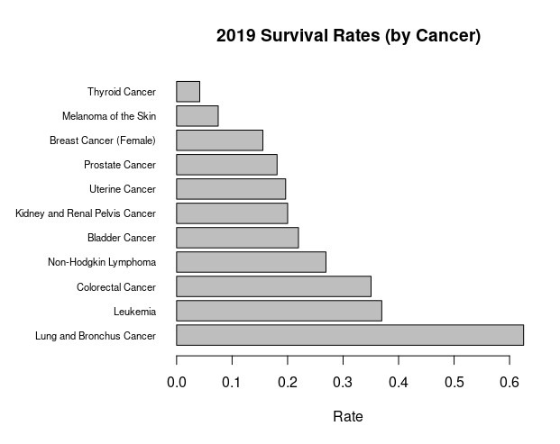